# spatial2

Meredith Franklin

9/6/2019

## Setup

### Packages and Data

Load the following packages and load the PM data from lecture 1. Select November 10th, 2018 and merge the data with the sites.

```r
library(ggplot2)
library(leaflet)
library(mapproj)
library(proj4)
library(geoR)
library(dplyr)

pm25 = read.csv("/Users/mf/Dropbox (University of Southern California)/Courses/PM569/Fall 2019/data/pm25_ca_2018.csv")
pm25.sites = read.csv("/Users/mf/Dropbox (University of Southern California)/Courses/PM569/Fall 2019/data/pm25_sites.csv")

pm_ca<-merge(pm25 %>% filter(date=="11/10/18"), pm25.sites, by='site_id')
```

Make a map of the PM2.5 concentrations

```r
pm.pal = colorNumeric(c('darkgreen','goldenrod','brown','brown'),
                        domain=pm_ca$pm25)
  leaflet(pm_ca) %>%
  addProviderTiles('CartoDB.Positron') %>%
  addCircles(lat=~latitude,lng=~longitude,label=~paste0(pm25, ' ug/m3'), color=~pm.pal(pm25),
             opacity=1, fillOpacity=1, radius=500) %>%
  addLegend('bottomleft', pal=pm.pal, values=pm_ca$pm25,
            title='PM2.5 (ug/m3)', opacity=1)
```

[interactive chart not shown]

## Projections

Recall that calculating distances is not very meaningful using latitude and longitude as it will be in degrees.

- first define the projection with the proj4 syntax
- look at two: California Albers (Teale Projection) and UTM zone 11 (specific to SoCal)

```r
proj_albers<-"+proj=aea +lat_1=34.0 +lat_2=40.5 +lon_0=-120.0 +x_0=0 +y_0=-4000000 +ellps=GRS80 +datum=NAD83 +units=km"
proj_utm11<-"+proj=utm +zone=11 +north +datum=WGS84 +units=km"

newcoords1<-project(as.matrix(cbind(pm_ca$longitude, pm_ca$latitude)), proj=proj_albers)
pm_ca$x_alb<-newcoords1[,1]
pm_ca$y_alb<-newcoords1[,2]


newcoords2<-project(as.matrix(cbind(pm_ca$longitude, pm_ca$latitude)), proj=proj_utm11)
pm_ca$x_utm<-newcoords2[,1]
pm_ca$y_utm<-newcoords2[,2]

pm_ca %>% head()
```

```
##    site_id     date pm25     city longitude latitude      x_alb     y_alb
## 1 60110007 11/10/18 59.7 Williams -122.2818 39.02122 -197.35842  114.0731
## 2 60111002 11/10/18 60.1   Colusa -121.9989 39.18919 -172.49722  132.1846
## 3 60190011 11/10/18 39.5   Fresno -119.7732 36.78538   20.21198 -136.8134
## 4 60190500 11/10/18 15.5   Friant -119.6583 36.98512   30.36945 -114.5818
## 5 60195001 11/10/18 30.9   Clovis -119.7164 36.81945   25.26073 -133.0131
## 6 60195025 11/10/18 39.0   Fresno -119.7330 36.72639   23.81404 -143.3605
##       x_utm    y_utm
## 1  42.64096 4332.425
## 2  68.18302 4349.691
## 3 252.53133 4074.652
## 4 263.40168 4096.525
## 5 257.70640 4078.287
## 6 255.93329 4068.003
```

## GeoR objects and exploratory maps

- Using the geoR package enables quick exploratory spatial analysis and basic maps
- We first create geodata objects to do data exploration and spatial distance calculations for semivariograms
- Let us compare geodata objects with lon/lat vs projected x/y

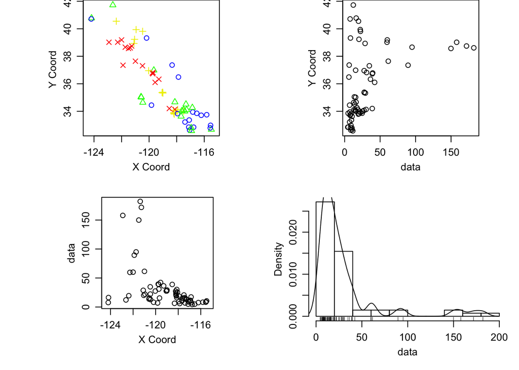

```r
pm_geo<-as.geodata(pm_ca,coords.col=c(5,6), data.col=3)
plot(pm_geo)
```

```r
summary(pm_geo)
```

```
## Number of data points: 68
##
## Coordinates summary
##     longitude latitude
## min -124.2014 32.57816
## max -115.4831 41.72689
##
## Distance summary
##         min         max
##  0.03433095 11.88475667
##
## Data summary
##      Min.   1st Qu.    Median      Mean   3rd Qu.      Max.
##   4.40000  10.12500  17.95000  30.64118  29.52500 182.10000
```

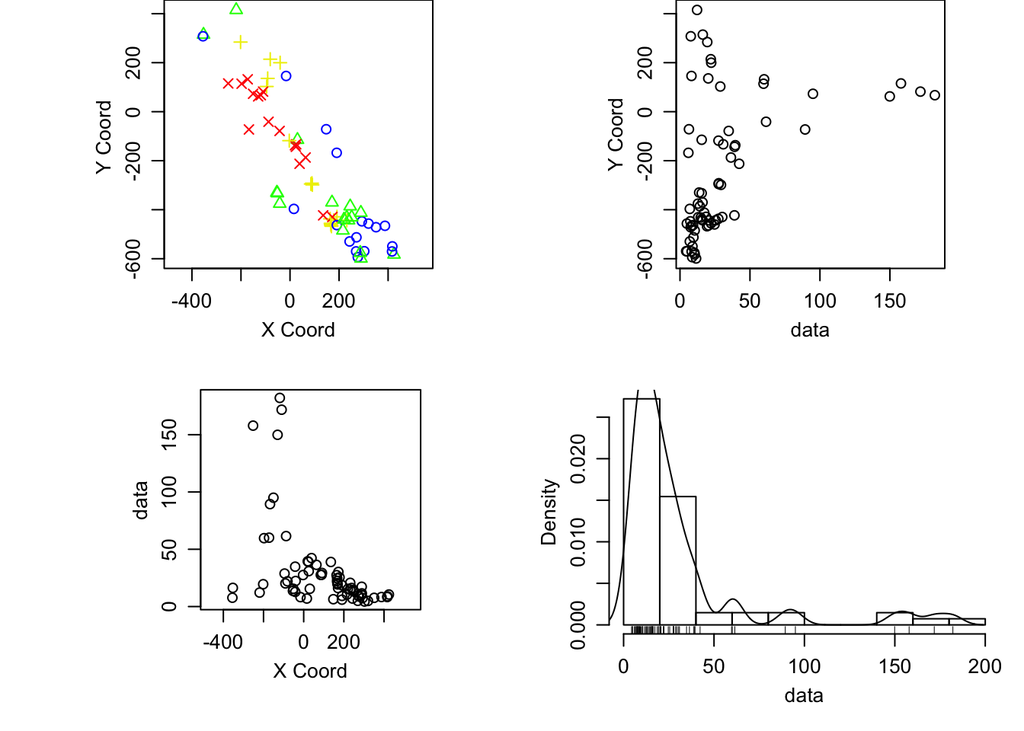

```r
pm_geo_alb<-as.geodata(pm_ca,coords.col=c(7,8),data.col=3)
plot(pm_geo_alb)
```

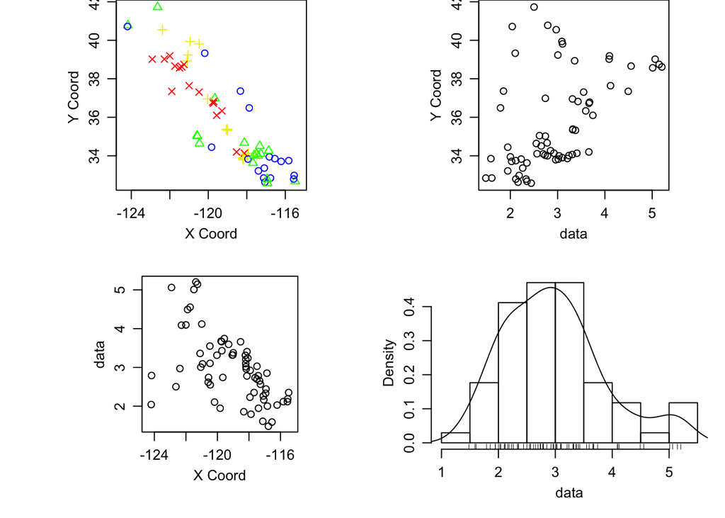

```r
# log pm25 might be better?
pm_ca$logpm25<-log(pm_ca$pm25)
lpm_geo<-as.geodata(pm_ca,coords.col=c(5,6),data.col=11)
plot(lpm_geo)
```

```r
lpm_geo_alb<-as.geodata(pm_ca,coords.col=c(7,8),data.col=11)
summary(lpm_geo_alb)
```

```
## Number of data points: 68
##
## Coordinates summary
##         x_alb     y_alb
## min -354.9670 -599.0421
## max  424.1254  415.1952
##
## Distance summary
##         min         max
##    3.607555 1187.488641
##
## Data summary
##     Min.  1st Qu.   Median     Mean  3rd Qu.     Max.
## 1.481605 2.314549 2.886934 2.972054 3.385151 5.204556
```

We can make basic but informative exploratory maps with geoR objects

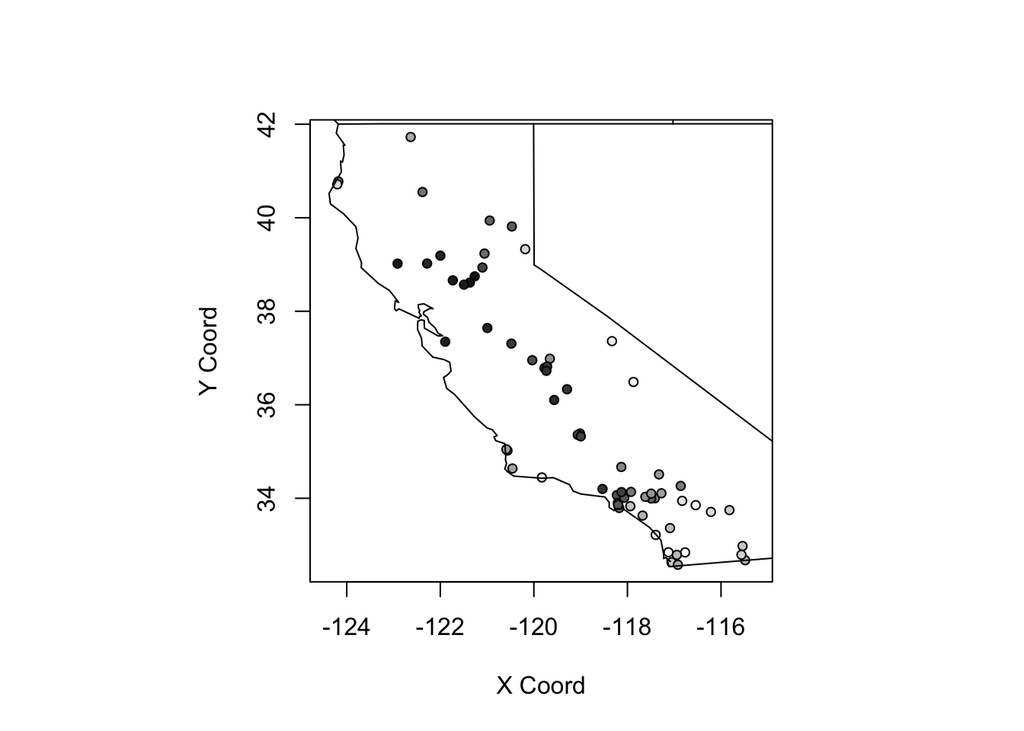

```r
# Plotting geoR objects as point data with different colour ramps
points(lpm_geo,cex.max=0.8,col=gray(seq(1, 0.1, l=100)), pt.div="equal")
# Add state boundaries to geoR plots
map("state",add=TRUE)
```

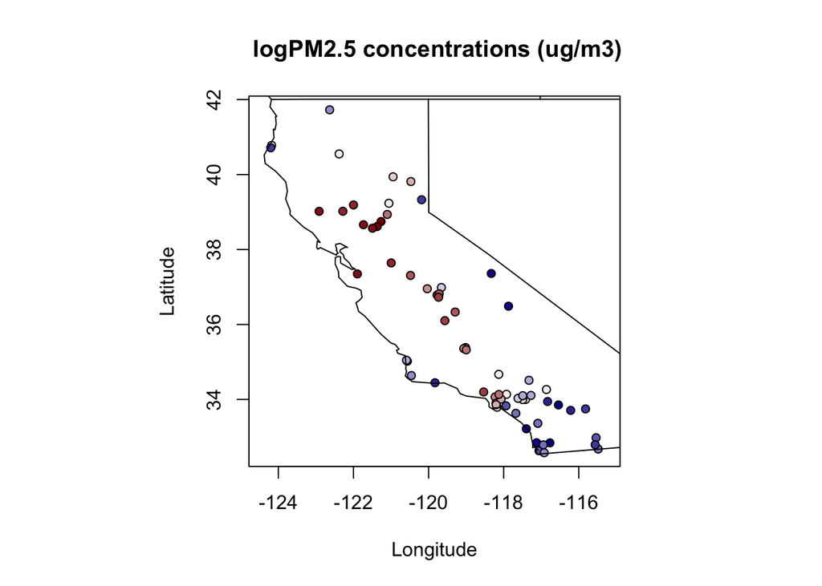

```r
# adding labels, colours, gradients
points(lpm_geo,cex.max=0.9,col= colorRampPalette(c("darkblue", "white", "darkred"))(20), pt.divide="equal",main=" logPM2.5 concentrations (ug/m3)",xlab="Longitude",ylab="Latitude")
map("state",add=TRUE)
```

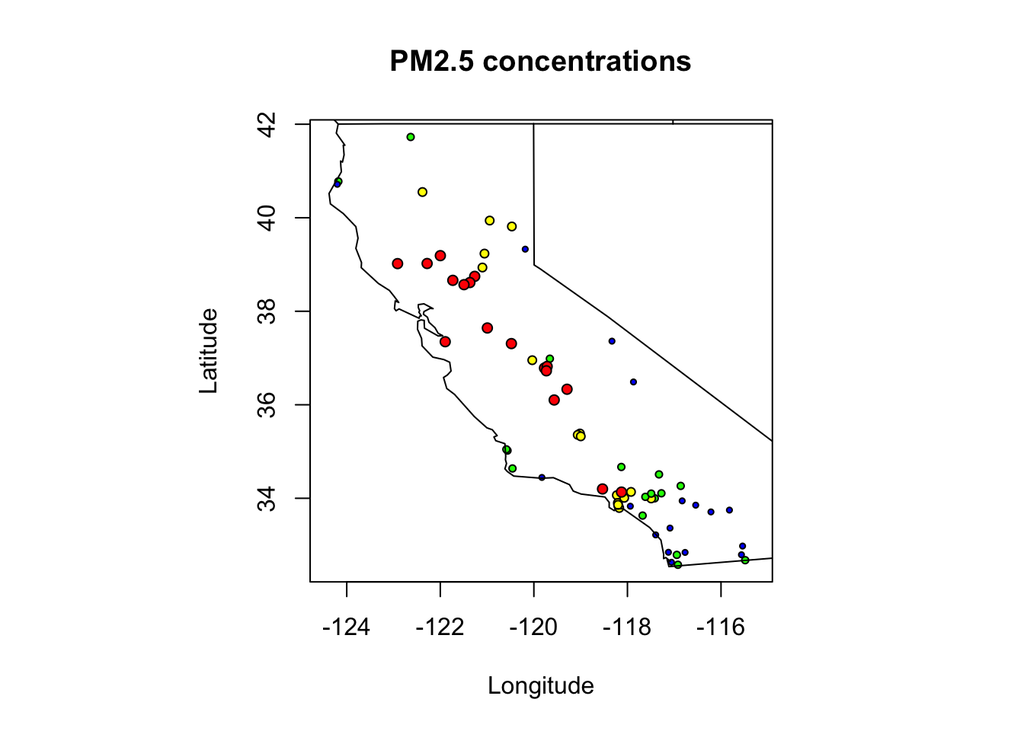

```r
# colours and sizes
points(lpm_geo,cex.max=0.9, pt.divide="quartiles", main="PM2.5 concentrations", xlab="Longitude",ylab="Latitude")
map("state",add=TRUE)
```

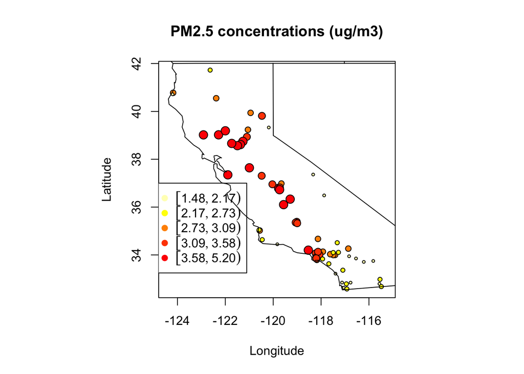

```r
# add crude legend
points(lpm_geo,col= rev(heat.colors(10)), x.leg= -125, y.leg=37, pt.divide="quintiles", main="PM2.5 concentrations (ug/m3)", xlab="Longitude",ylab="Latitude")
map("state",add=TRUE)
```

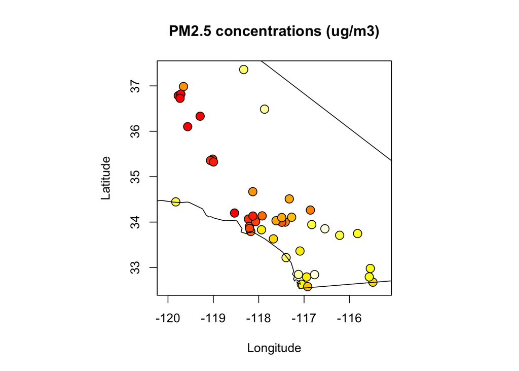

```r
# subset geodata to look at a particular region

lpm_geo_ss<-subset(lpm_geo,longitude> -120  & latitude<42)
points(lpm_geo_ss,col= rev(heat.colors(20)), pt.div="equal", main="PM2.5 concentrations (ug/m3)", xlab="Longitude",ylab="Latitude")
map("state",add=TRUE)
```

## Empirical Semivariograms

We will build empirical semivariograms including cloud, bin, boxplot bin

- use Albers projection so distances are in km
- semivariogram cloud plots semivariance at all pairwise distances
- binned semivariogram averages semivariances by distance bins. The components of the binned semivariogram are distance range (min, max) and number of bins.
- binned semivariogram boxplots can be informative to see how much data are in each bin.
- the Cressie-Hawkins “robust” estimate of semivariance is tuned to deal with outliers and is often preferred. Its effect is really clear in the boxplot semivariograms.

```r
# cloud semivariogram (all pairwise points)
vario1<-variog(lpm_geo_alb,option="cloud")
```

```
## variog: computing omnidirectional variogram
```

```r
vario1$max.dist
```

```
## [1] 1187.489
```

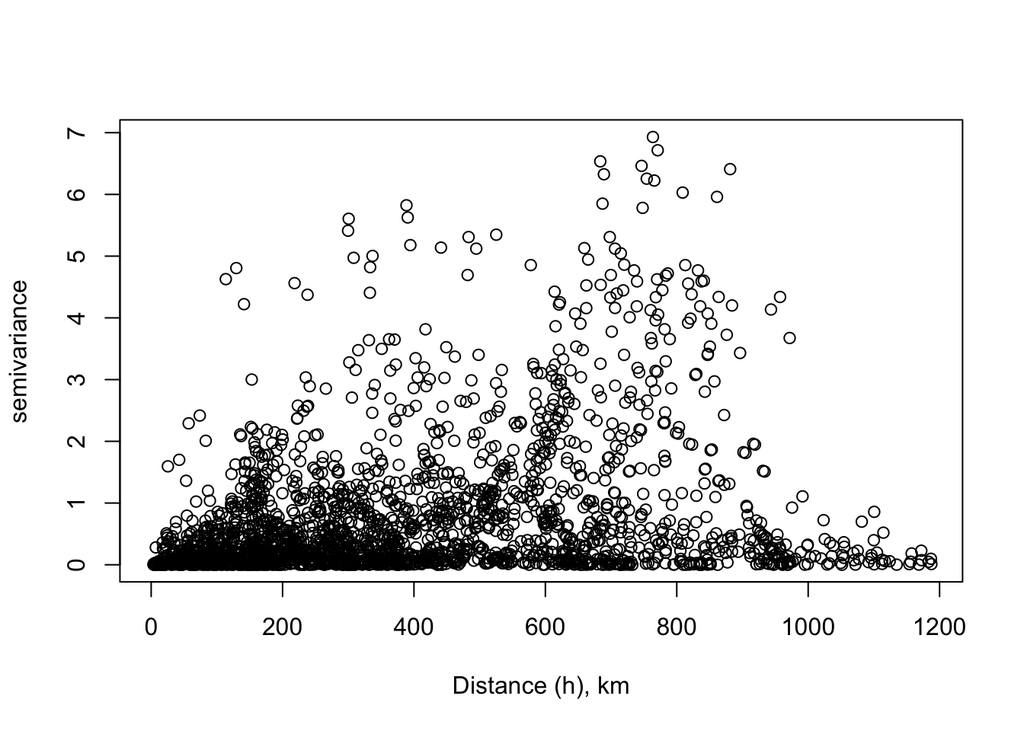

```r
plot(vario1,xlab="Distance (h), km")
```

```r
# binned semivariogram
vario2<-variog(lpm_geo_alb,uvec=seq(0,vario1$max.dist,l=15),option="bin")
```

```
## variog: computing omnidirectional variogram
```

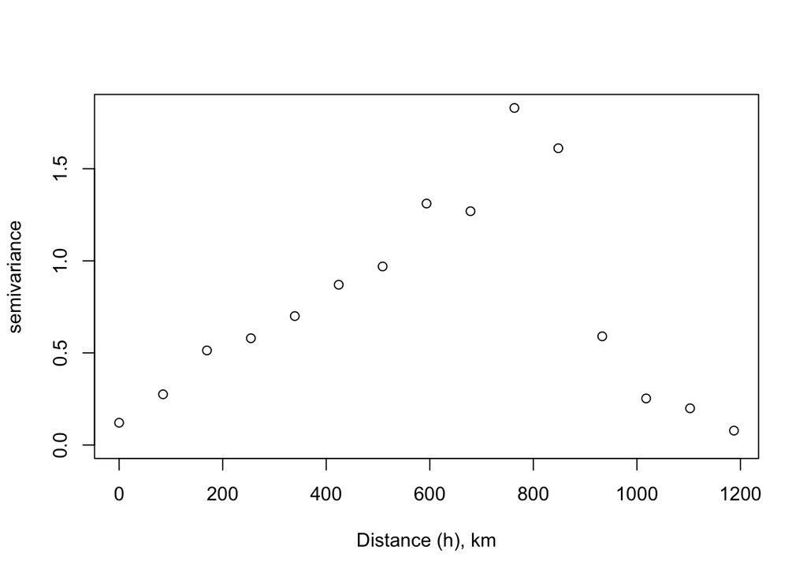

```r
plot(vario2,xlab="Distance (h), km")
```

```r
# shorter maximum distance more bins
vario3<-variog(lpm_geo_alb,uvec=seq(0,800,l=20),option="bin")
```

```
## variog: computing omnidirectional variogram
```

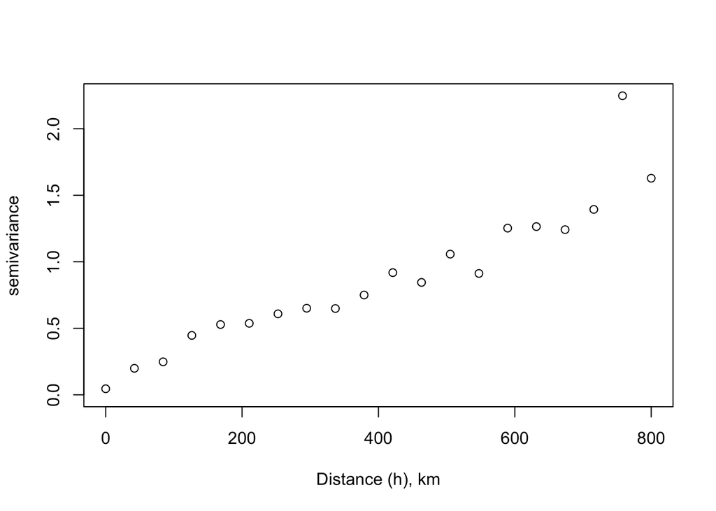

```r
plot(vario3,xlab="Distance (h), km")
```

```r
# shorter yet
vario3b<-variog(lpm_geo_alb,uvec=seq(0,200,l=15),option="bin")
```

```
## variog: computing omnidirectional variogram
```

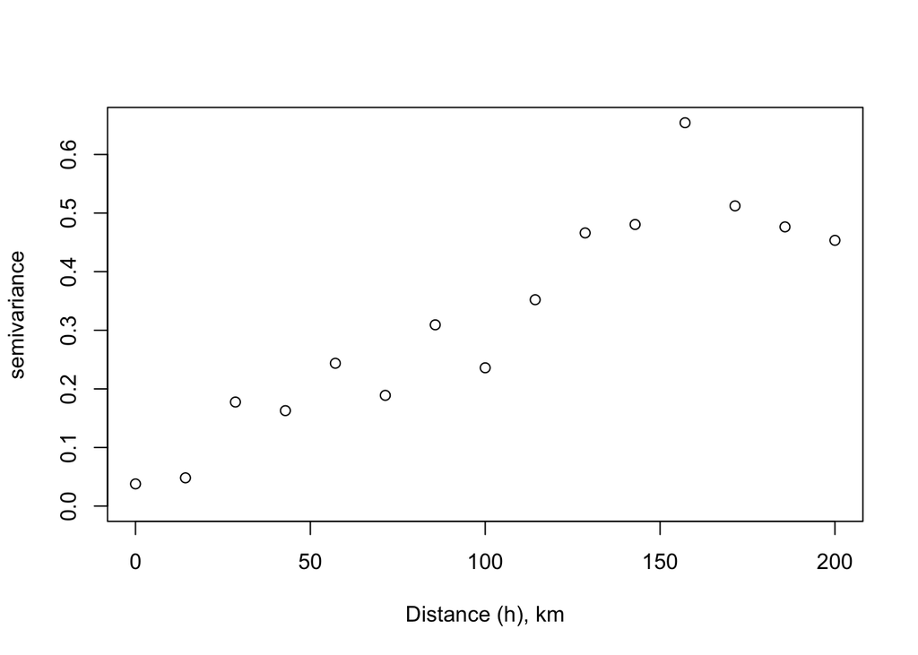

```r
plot(vario3b,xlab="Distance (h), km")
```

```r
# boxplots
vario4<-variog(lpm_geo_alb,uvec=seq(0,vario1$max.dist,l=20),bin.cloud=T)
```

```
## variog: computing omnidirectional variogram
```

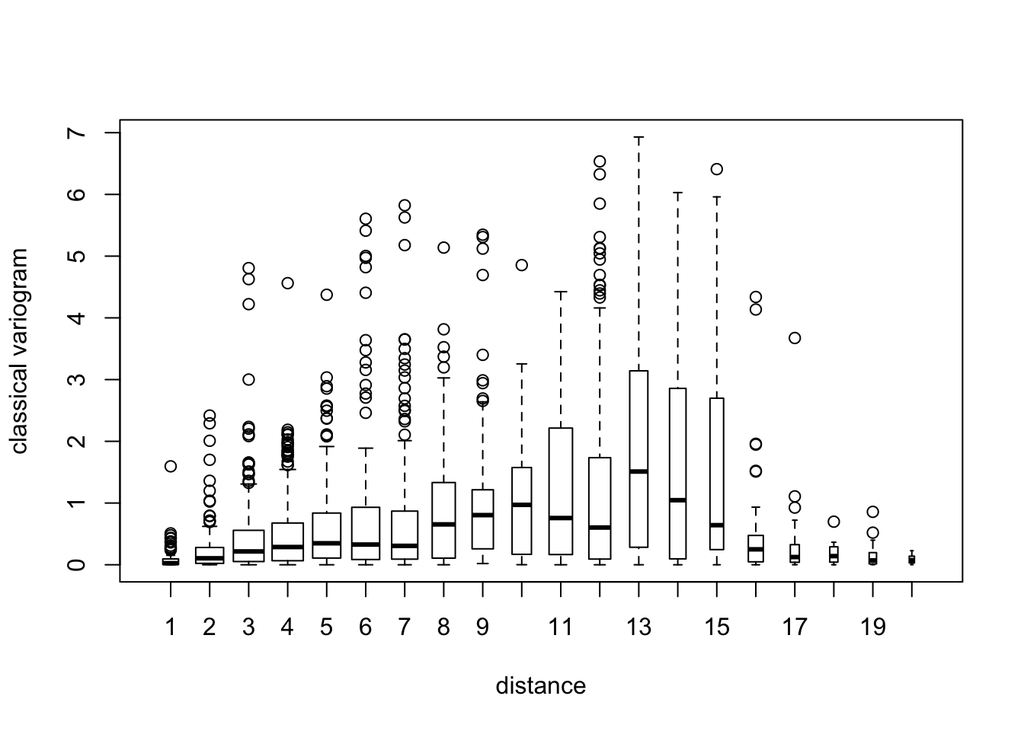

```r
plot(vario4,bin.cloud=T,xlab="Bin")
```

```r
vario4b<-variog(lpm_geo_alb,uvec=seq(0,200,l=20),bin.cloud=T)
```

```
## variog: computing omnidirectional variogram
```

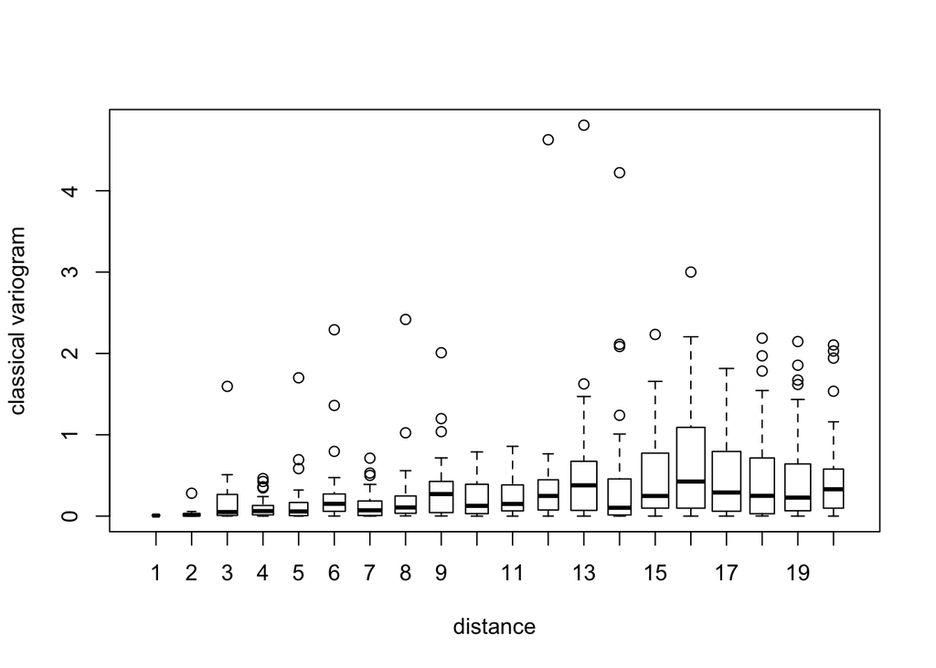

```r
plot(vario4b,bin.cloud=T,xlab="Bin")
```

```r
# Robust estimator "modulus" is preferred
vario2m<-variog(lpm_geo_alb,uvec=seq(0,200,l=12),option="bin",estimator.type="modulus")
```

```
## variog: computing omnidirectional variogram
```

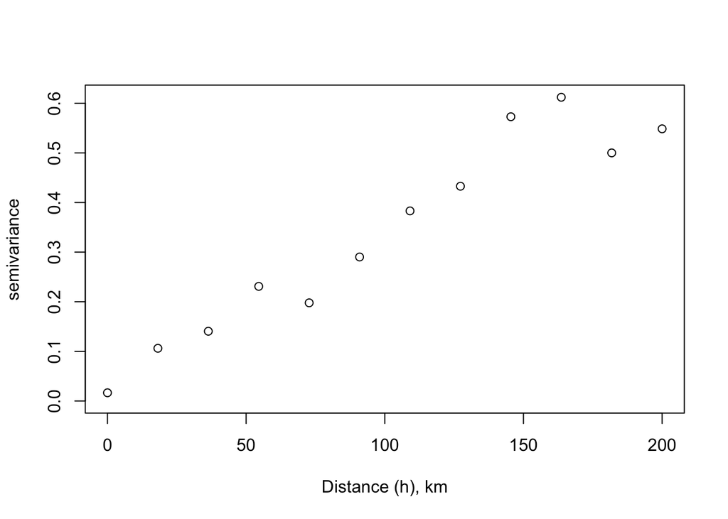

```r
plot(vario2m,xlab="Distance (h), km")
```

```r
vario4m<-variog(lpm_geo_alb,uvec=seq(0,200,l=20),bin.cloud=T,estimator.type="modulus")
```

```
## variog: computing omnidirectional variogram
```

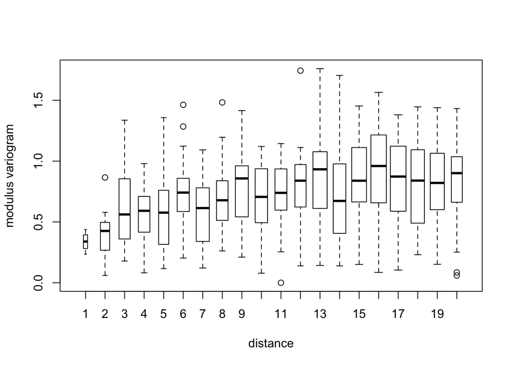

```r
plot(vario4m,bin.cloud=T,xlab="Distance (h), km")
```

## Theoretical semivariograms by curve fitting

- We use the “eyeball” method to fit some theoretical semivariograms to our empirical data
- It is best to do this with the binned semivarigrams (robust estimator)
- Using the equations from class we will fit the exponential and spherical functions with our best guesses for the nugget, sill and range
- Curve fitting can generally be done using the curve() function. You need to supply the equation, the range in x that you want to plot (min, max distance), and any other options such as y limits, colors, titles, etc.

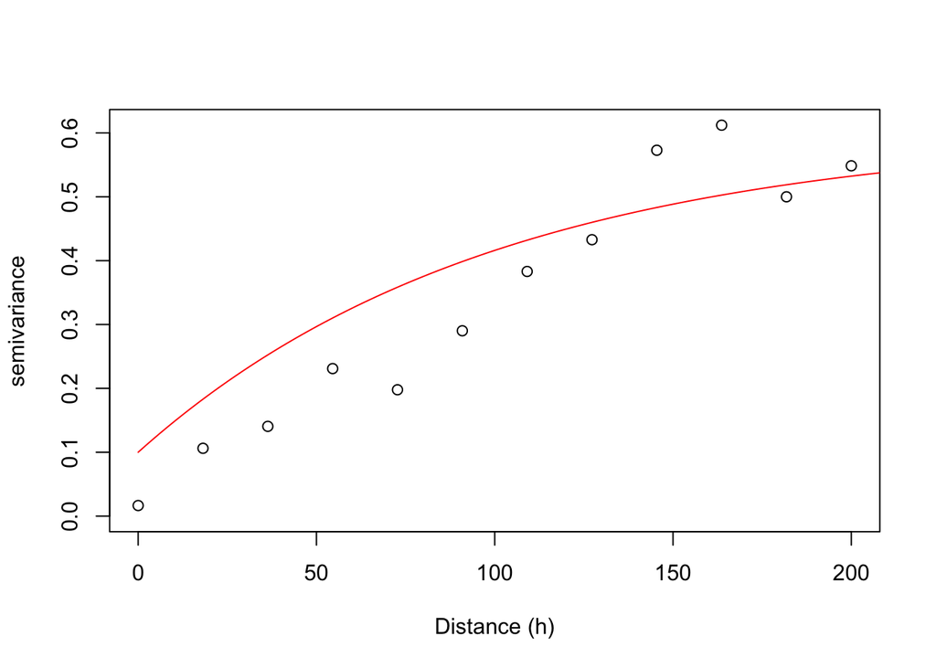

```r
# Exponential

plot(vario2m,xlab="Distance (h)")
curve(0.1+0.5*(1-exp(-x/100)),from = 0 , to=vario2m$max.dist, col="red",ylab="Semivariance", xlab="Distance (h)",ylim=c(0,0.6),add=T)
```

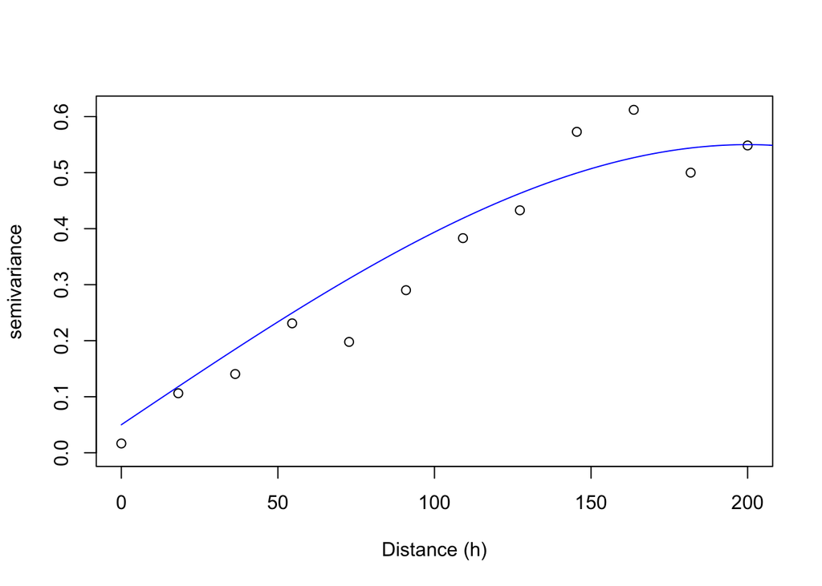

```r
# Spherical
plot(vario2m,xlab="Distance (h)")
curve(0.05+0.5*(1.5*(x/200)-0.5*(x/200)^3),from = 0 , col="blue",to=vario2m$max.dist, ylab="Semivariance", xlab="Distance (h)",add=T)
```

## Anisotropy

- If we look at the semivariogram from different angles we can see if we are violating stationarity by direction
- variog4 in the geoR library let’s us visualize the directional differences

```r
# Exploring anisotropy (introduction for next lecture)

vario.dir<-variog4(lpm_geo_alb,uvec=seq(0,800,l=25),option="bin",estimator.type="modulus")
```

```
## variog: computing variogram for direction = 0 degrees (0 radians)
##         tolerance angle = 22.5 degrees (0.393 radians)
## variog: computing variogram for direction = 45 degrees (0.785 radians)
##         tolerance angle = 22.5 degrees (0.393 radians)
## variog: computing variogram for direction = 90 degrees (1.571 radians)
##         tolerance angle = 22.5 degrees (0.393 radians)
## variog: computing variogram for direction = 135 degrees (2.356 radians)
##         tolerance angle = 22.5 degrees (0.393 radians)
## variog: computing omnidirectional variogram
```

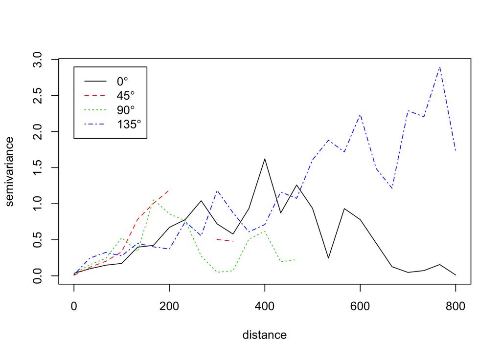

```r
plot(vario.dir)
```

```r
vario.dir2<-variog4(lpm_geo_alb,uvec=seq(0,200,l=15),option="bin",estimator.type="modulus")
```

```
## variog: computing variogram for direction = 0 degrees (0 radians)
##         tolerance angle = 22.5 degrees (0.393 radians)
## variog: computing variogram for direction = 45 degrees (0.785 radians)
##         tolerance angle = 22.5 degrees (0.393 radians)
## variog: computing variogram for direction = 90 degrees (1.571 radians)
##         tolerance angle = 22.5 degrees (0.393 radians)
## variog: computing variogram for direction = 135 degrees (2.356 radians)
##         tolerance angle = 22.5 degrees (0.393 radians)
## variog: computing omnidirectional variogram
```

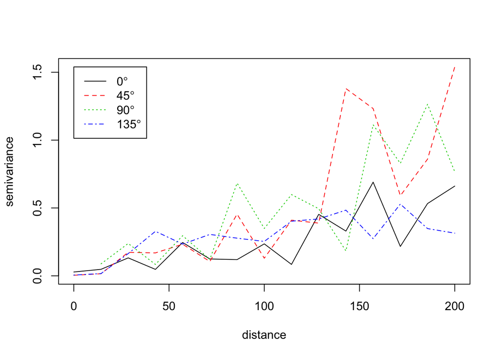

```r
plot(vario.dir2)
```